# Endocrine Pathway Analysis Example

Here, I am going to show an example of some first steps toward analyzing what is happening to DHEA

Load in libararies

```r
library(biomaRt)
library(Seurat)
library(tidyverse)
library(lme4)
library(car)
library(emmeans)
library(igraph)
library(ggraph)
```

Load in Seurat Object (modify to your system path here)

```r
obj <- readRDS("C:/Users/Gabe/Desktop/RNA Object.rds")
```

Read in human to ocellaris.csv (I think I sent you this but if not it’s on my github:

https://github.com/ggraham4/multiome_poa/blob/main/Reference/hsapiens_to_aocellaris.csv

```r
human_to_ocellaris <- read_csv("C:/Users/Gabe/Desktop/multiome_poa/Reference/hsapiens_to_aocellaris.csv")
```

```
## ──────────────────────────────────────────────────────── Delimiter: "," chr
## (2): hsapiens_name, aocellaris_name dbl (2): ...1, X
```

## Setting up biomaRt

biomaRt provides access to a variety of online databases largely regarding information about genes. This includes a wide variety of things like orthologs from one species to another (that’s how hsapiens_to_ocellaris.csv was made), gene length, gene chromosome location, and much more that I wont go into here.

Relevant to our idea here, biomaRt provides gene ontology (GO) terms, that describes the biological process a gene plays a role in. GO terms are essentially hierarchical, meaning if a gene plays a role in lets say “androgen biosynthesis”, it will also be classified as playing a role in “steroid hormone metabolism”, “cholesterol metabolism”, “oxioreductase activity” etc., because those are all more generic ways of describing androgen biosynthesis. Additionally, genes are often enriched for several GO terms simply because they have several functions. Thus, each gene has several GO terms. Lets see what we can do with this info below.

Connect to human biomart - the reason I am using the human biomart and not the A ocellaris biomaRt is because the human genome is MUCH better annotated than the clownfish genome, so we can borrow some human information and transfer it to clownfish genes

```r
human_mart <- useEnsembl(biomart = 'genes',
                             dataset = 'hsapiens_gene_ensembl')
```

List the attributes available to human_mart: view(att) to see all things you could learn about a gene

```r
att = attributes(human_mart)$attributes
head(att)
```

```
##                            name                  description
## 1               ensembl_gene_id               Gene stable ID
## 2       ensembl_gene_id_version       Gene stable ID version
## 3         ensembl_transcript_id         Transcript stable ID
## 4 ensembl_transcript_id_version Transcript stable ID version
## 5            ensembl_peptide_id            Protein stable ID
## 6    ensembl_peptide_id_version    Protein stable ID version
##                          fullDescription         page                   NA
## 1                  Stable ID of the Gene feature_page html,txt,csv,tsv,xls
## 2       Versionned stable ID of the Gene feature_page html,txt,csv,tsv,xls
## 3            Stable ID of the Transcript feature_page html,txt,csv,tsv,xls
## 4 Versionned stable ID of the Transcript feature_page html,txt,csv,tsv,xls
## 5                                        feature_page html,txt,csv,tsv,xls
## 6                                        feature_page html,txt,csv,tsv,xls
##                                         NA                                  NA
## 1        hsapiens_gene_ensembl__gene__main                      stable_id_1023
## 2        hsapiens_gene_ensembl__gene__main        gene__main_stable_id_version
## 3  hsapiens_gene_ensembl__transcript__main                      stable_id_1066
## 4  hsapiens_gene_ensembl__transcript__main  transcript__main_stable_id_version
## 5 hsapiens_gene_ensembl__translation__main                      stable_id_1070
## 6 hsapiens_gene_ensembl__translation__main translation__main_stable_id_version
```

Query info from human biomaRt; this may take a moment

```r
human_go <- getBM(mart = human_mart, #call the human mart
                      attributes = c('entrezgene_accession', #entrezgene_acession is the NIH gene name
                                     'go_id', #go ID
                                     'name_1006' # name_1006 is the GO term
                      ))
```

Join the human mart to the human to ocellaris gene translation - adds human GO terms to aocellaris genes

```r
joined <- human_to_ocellaris%>% #%>% pipe operator passes this argument to the next function
  right_join(human_go, by =join_by('hsapiens_name' == 'entrezgene_accession'))%>% #right join tacks one data frame onto another based on a common column: in this case, hsapeinens name corresponds to entrezgene acession
  subset(!is.na(hsapiens_name)& #remove missing or empty gene names
           hsapiens_name != ''&
           !is.na(aocellaris_name)& # an important not here is you cannot say aocellaris_name != NA, dealing with NAs (and NaNs and NULLs) requries a special helper function is.na()
           aocellaris_name != '')
```

Subset to genes enriched for a specific GO term; as an example we can do a very generic one like ‘steroid metabolic process’

```r
genes_subset <- joined%>%
  subset(name_1006 == 'steroid metabolic process') #subsets the whole df

steroid_metabolism_genes = unique(genes_subset$aocellaris_name) # make a list of all unique a ocellaris genes in the above df
head(steroid_metabolism_genes)
```

```
## [1] "hsd11b2"      "slc22a15"     "stard3"       "hsd3b7"       "LOC111563640"
## [6] "LOC111586556"
```

Some of these are genes we are familiar with; HSD family members

# What exactly do we want to ask?

I think what we are trying to ask is a few things

1. What is the most likely enzymatic pathway DHEA is being metabolized in
2. Do the sexes differ in the expression of this pathway or its constituents

My feeling is the best way to ask **1** is to ask which genes are most likely to occur in a series (and this is a big assumption) that they constitute a pathway. Of course this will need to be validated with literature.

## Data Preparation

Because our data is heavily 0 inflated (it is mostly 0s), we should pseudobulk the expression of each gene. Pseudobulking is taking the mean expression of a gene in an individual across all nuclei in a cluster.

```r
steroid_gene_data <- obj@assays$RNA$data[steroid_metabolism_genes,] %>%t()%>%as.data.frame() #transpose so that CELLS ARE NOW ROWS AND GENES ARE NOW COLUMNS

steroid_gene_data$individual = obj$individual #add meta data to list
steroid_gene_data$Status = obj$Status #
steroid_gene_data$harmony.wnn_res0.4_clusters = obj$harmony.wnn_res0.4_clusters

steroid_gene_data <- steroid_gene_data%>%
  group_by(individual, Status, harmony.wnn_res0.4_clusters)%>% #group by variables we care about
  summarize(across(all_of(steroid_metabolism_genes), mean, .names = "{.col}")) #summarize the mean for each gene across those variables
```

Before I do any stats, I want to give the clownfish genes human gene names for the simple reason that most clownfish genes are named like LOC111577263 and human genes are easier to read. There is also the caveat that several ocellaris genes will align to one human gene.

```r
#Extract gene names from steroid gene data
gene_names = colnames(steroid_gene_data[,4:ncol(steroid_gene_data)])

#Define a function to translate the gene names
get_human_names <- function(ocellaris_names) {
  sapply(ocellaris_names, function(gene) { #sapply applies a function across a vector into a list
    idx <- which(human_to_ocellaris$aocellaris_name == gene) #which asks which row indecies are true
    if(length(idx) > 0) { #if there is a match
      return(human_to_ocellaris$hsapiens_name[idx[1]]) #return the first result (there are often several matches)
    } else { #else
      return(gene) #keep the clownfish gene
    }
  })
}

human_names <- get_human_names(gene_names) #run the function

colnames(steroid_gene_data)[4:ncol(steroid_gene_data)] <- human_names #rename the relevant colnames using our new vector
```

## Correlation Matrix

In a broad search, we dont care so much about sex differences, we just want to ask which genes are correlated. Above, we grouped by individual and cluster, so each data point will be one individual within one cluster, and we will be correlating across these levels.

```r
#cor creates a correlation matrix from a matrix
correlation_matrix = cor(as.matrix(steroid_gene_data[,4:ncol(steroid_gene_data)]))
```

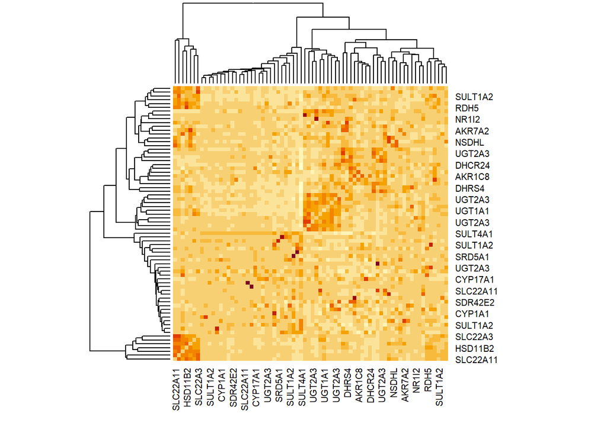

```r
#remove any rows or columns tthat are NAs
na_rows <- which(is.na(correlation_matrix[,1]))
na_cols <- which(is.na(correlation_matrix[1,]))

correlation_matrix = correlation_matrix[-na_rows, -na_cols]

diag(correlation_matrix) = 0 #we dont care that a gene correlates with itself

#first visualization - heatmap
heatmap(correlation_matrix)
```

## Network Graph

Another way to visualize this is using a network graph, which finds networks for correlated items (in this case genes)

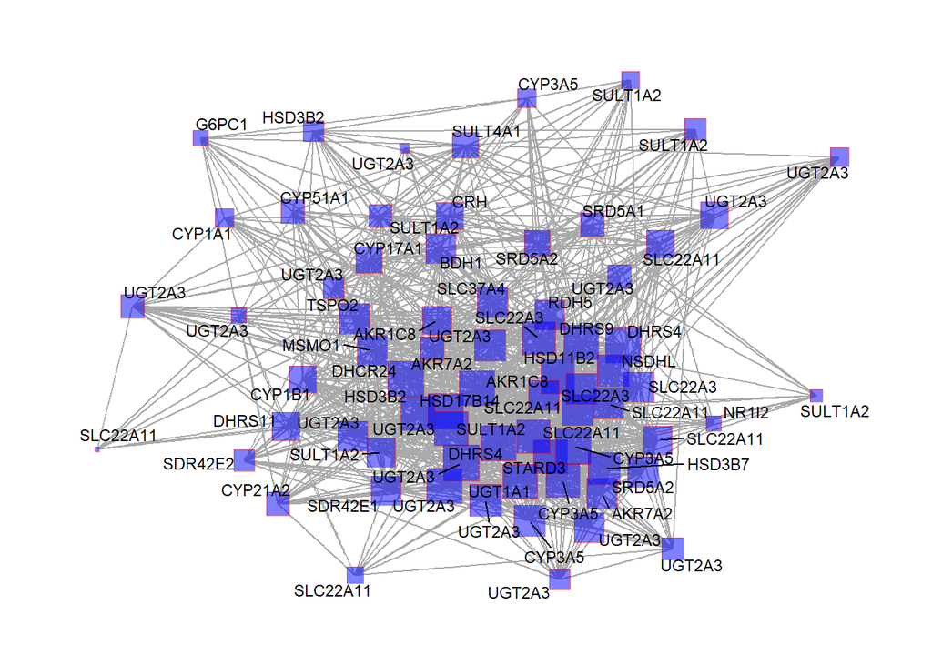

```r
#Define a threshold because the whole matrix would be a mess
signif_interaction_value =0

#Subset the correlation matrix based on that value such that there are no negative correalations
top_correlation_matrix = ifelse(correlation_matrix<signif_interaction_value, 0, correlation_matrix)

#make an undirected igraph
g <- graph_from_adjacency_matrix((top_correlation_matrix), mode = "undirected", weighted = TRUE)

#remove vertecies that have no connections
Isolated = which(degree(g)==0)
g = delete_vertices(g, Isolated)

#plot using ggraph
ggraph(g, layout = 'fr')+
  geom_edge_link(color = "darkgray") +
  geom_node_point(
    fill = "blue",
    color = "red",
    alpha = 0.5,
    shape = 22,
    aes(size = igraph::degree(g)),
    show.legend = FALSE
  ) +
  scale_size(range = c(1, 10)) +
  geom_node_text(aes(label = name),size =3, repel =T)+
  theme_graph()
```

# Hypothesis Testing Using a Random Walk

A random walk is an approach to asses inherently random processes. In our enzymatic pathway for example, lets say the correlation coefficient between HSD3B1 and HSD17B14 is 0.6. One interpretation could be that given a molecule that is processed by HSD3B1, there is a 60% chance it is passed to HSD17B14, and the same concept can be applied to the next enzyme after HSD17B14. Even though there is a 60% chance the molecule is passed to HSD17B14, for a single event, it is completely random where it ends up going. In a random walk, a node (gene) is selected as a starting point, and then based on the edge weight (correlation coefficient between the two genes), the walker chooses to step to the next node based on the correlation between the two nodes. Thus, 60% of the time, it will go from HSD3B1 to HSD17B14. After that, it then has a probability of going to the next node and the next node etc. By simulating a random walk thousands of times, we can see which pathway occurs the most frequently and is thus the most likely.

Here, as an example, we will run the random walk once. We set a starting node on the graph and specify the number of steps for the walker to take. We then look at which nodes (vertices) the walker traveled to

```r
walk <-  random_walk(g,
                 4, #starting vertex (node), call V(g) to see the names of each vertex
                 4) #number of steps the walker will take

names(walk) # the steps the walker took
```

```
## [1] "HSD3B7" "DHRS4"  "UGT1A1" "AKR7A2" "CYP3A5"
```

A single random walk doesnt tell us that much though, so we need so simulate thousands of walks to feel confident about a result. Here, we stimulate it 3000 times.

```r
out_data <- data.frame() #initialize empty data frame to put data into
for(i in 1:3000){ #specify number of iterations
  path <- random_walk(g,
                      4,#starting node
                      4 #steps
                      )
  steps <- names(path) #see which steps the walker took
  newd <- data.frame(steps = steps, #add to data frame
                     n_step = 1:5,
                     iter = i)
  out_data = rbind(newd, out_data) #bind new data to out_data
}
```

Then, convert to probabilities by dividing by number of iterations

```r
probability_data <- as.data.frame.matrix( #make a matrix from a table
  table(
    out_data$steps, out_data$n_step #that is x = 'which step', and y = 'gene', where cells are the frequency that gene was that step
    )/max(out_data$iter)) #divide by total number of iteration

head(probability_data) #for the first step, all but node 1 will have a probability of 0 because we set node 1 to be the first step when we defined the walk
```

```
##         1           2            3           4           5
## AKR1C8  0 0.027333333 0.0230000000 0.024666667 0.024666667
## AKR7A2  0 0.000000000 0.0380000000 0.039333333 0.036000000
## BDH1    0 0.000000000 0.0033333333 0.006000000 0.006666667
## CRH     0 0.004333333 0.0023333333 0.004333333 0.007666667
## CYP17A1 0 0.000000000 0.0016666667 0.004666667 0.005000000
## CYP1A1  0 0.001666667 0.0006666667 0.001000000 0.001000000
```

We can then extract a consensus path based on which gene was the most likely for each step. I think technically there is a more precise way to do this, but for our purposes I think this is ok.

```r
most_likely_path <- c(
  `1` = rownames(probability_data[probability_data$`1` == max(probability_data$`1`),]),
  `2` = rownames(probability_data[probability_data$`2` == max(probability_data$`2`),]),
  `3` = rownames(probability_data[probability_data$`3` == max(probability_data$`3`),]),
  `4` = rownames(probability_data[probability_data$`4` == max(probability_data$`4`),])
)
most_likely_path
```

```
##        1        2        3        4
## "HSD3B7" "CYP3A5" "UGT2A3" "UGT2A3"
```

### Convergence

Convergence is the idea that as you repeat a random process thousands of times, the probability of a given event converges to a single number. Convergence is important for a variety of reasons, but most importantly it allows us to be confident that our result is real and not due to random noise.

We rerun the simulation but this time we store the frequency of the most likely node at each step. Then, we can see how it changes over a number of iterations. We will do it 10,000 times, which takes a bit of time to run.

```r
conv_data <- data.frame()
temp_data <- data.frame()
for(i in 1:10000){
  path <- random_walk(g,
                      4,#starting node
                      4 #steps
                      )
  steps <- names(path)
  newd <- data.frame(steps = steps,
                     n_step = 1:5,
                     iter = i)

    temp_data <- rbind(temp_data, newd)

    freq_data <- as.data.frame.matrix(table(temp_data$steps, temp_data$n_step)/i)
    #the same probability data above normalized for the given iteration we are on

    #store the frequency of the most likely gene for each step
    frequency_2 <- max(freq_data$`2`)
    frequency_3 <- max(freq_data$`3`)
    frequency_4 <- max(freq_data$`4`)

    iter_freq <- data.frame(
      n_iter = i,
      frequency_2=frequency_2,
      frequency_3 = frequency_3,
      frequency_4=frequency_4
    )

  conv_data = rbind(iter_freq, conv_data)

}
```

Convergence is often assessed by looking at a plot of probability over iteration. We are looking for the probability to essentially stabilize and become flat as the number of iterations increase.

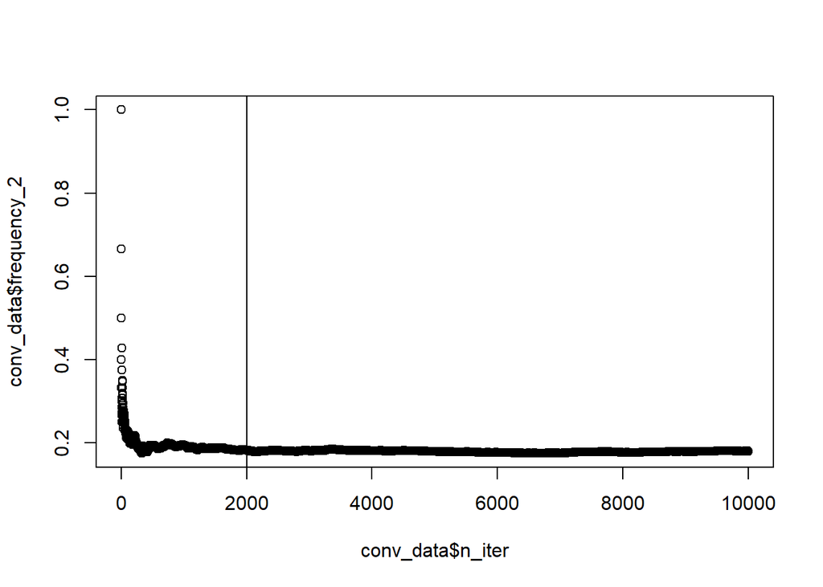

```r
plot(x = conv_data$n_iter, y = conv_data$frequency_2)
abline(v =2000)
```

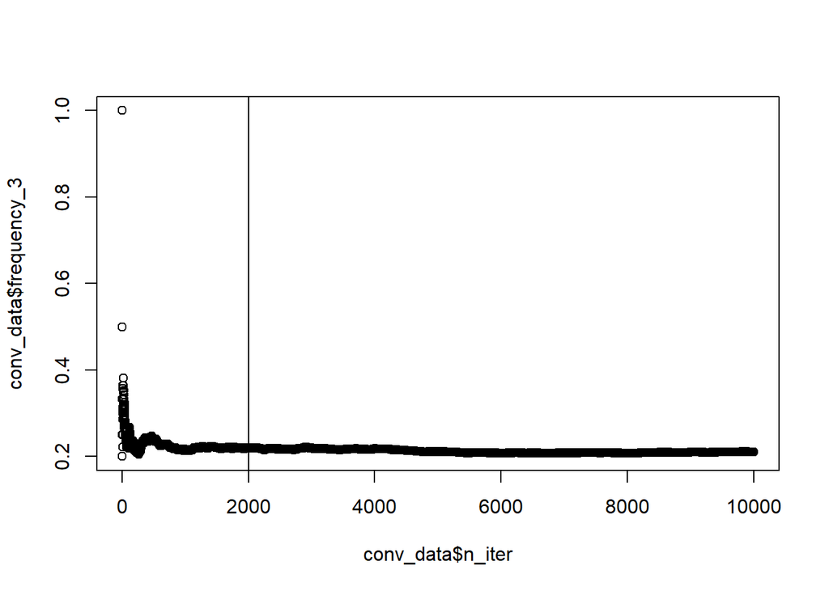

```r
plot(x = conv_data$n_iter, y = conv_data$frequency_3)
abline(v =2000)
```

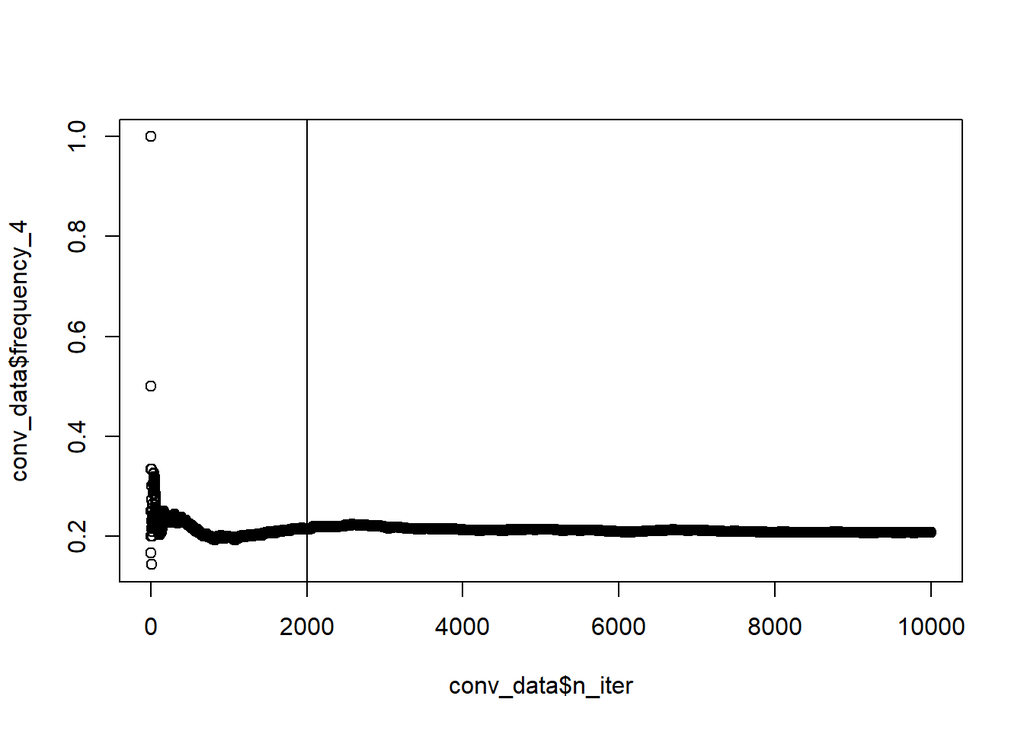

```r
plot(x = conv_data$n_iter, y = conv_data$frequency_4)
abline(v =2000)
```

We can see that after around 1000 - 2000, iterations, each step has converged